# Bayesian optimization

20/10/2025

## Goals

1. Showing the interest of planning experiments
2. Identifying and formalizing design of experiments problems

Note: lecture material adapted from [V. Picheny](https://sites.google.com/site/victorpicheny/) lectures on Design of experiments

## Historical example

The cornerstones of modern design principles are generally attributed to R.A. Fisher and F. Yates for their research in the 1920s.

They worked on data from crop experiments.

They analyzed the effects of manure, nutrients, location, sun exposure, plant variability, etc, on yield.

*Example on Spring Barley from [1](https://www.sciencedirect.com/handbook/handbook-of-statistics/vol/13/suppl/C)*

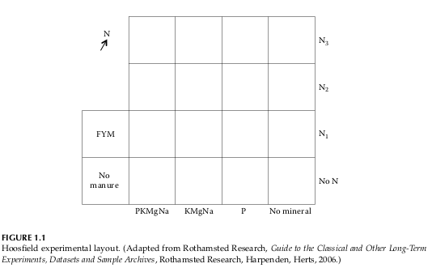

## Formalisation

[figure not shown]

Design of experiments (with n plants):

- how to select the variables’ values?
- how to exploit the results?
- (possibly) how many plants for each configuration?

## A “modern” example

(Convolutional) neural networks show great promises on many problems, but finding an appropriate structure can be time consuming.

These are the so-called **hyperparameter tuning** problems.

*MNIST example*:

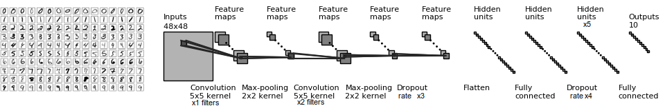

Design variables:

- kernel size, number of filters, number of layers
- dropout rates

“Noise” factors:

- dropout
- initialization
- data set partition

## Other examples

Design of experiments are crucial in many fields:

**Medicine and pharmacology**:

- clinical trials

**Social science**:

- behavioral experiments

**Marketing:**

- stated choice experiments
- web/email page design

**Industry:**

- material science
- aeronautics, car industry,…

## Physical vs computer experiments

**Physical experiments**:

- *noisy*
- repeatable
- costly ($)
- low dimension (small number of design variables)
- simple input/output relationship

**Computer experiments**:

- *deterministic* (in fact, less and less)
- costly (time)
- high dimension (many variables)
- more complex input/output relationship due to larger range of study

## Design of experiments goals

A good design of experiments must be able to support a great variety of models, provide information on the entire experimental domain with as few simulations as possible.

Associated questions:

**Sensitivity analysis**: what are the most influential factors?

**Learning/prediction**: how to obtain the best model?

**Optimization**: find the best configuration

## Sketch of solutions

Broad ideas:

1. *Geometrical* considerations
   - one factor at a time
   - all possible combinations
2. Global design space exploration considerations
3. A priori information on the phenomena:
   - *example*: linear dependence of the output on variables
   - *or* spatial dependence
4. Is it possible to iterate?
1. relates to **geometrical** designs
2. ” to **space-filling** designs
3. ” to **optimal** designs
4. ” to **sequential** designs

## Overview of classical design of experiments

## Notations

[figure not shown]

Design of experiments: set of \(n\) design values with the corresponding output(s) (observations).

Design matrix: \(\mathbf{X} = (\mathbf{x}^{(1)}, \dots, \mathbf{x}^{(n)})^\top\)

Vector of outputs (one measured output): \(\mathbf{Y} = (y_1, \dots, y_n)^\top\)

## One-at-a-time designs

**Goal**: identify the influence of each variable individually by fixing all other variables to their mean.

One experiment at the center + one varying one parameter (\(\times d\))  
=> \(d+1\) experiments

[figure not shown]

## Other 2-levels designs

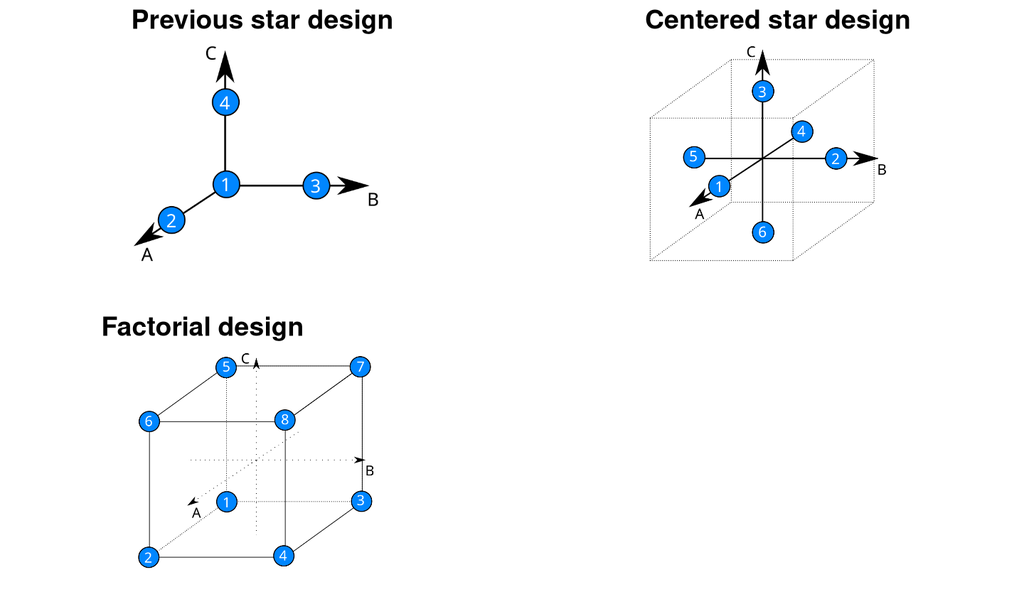

## Remarks on these 2-levels designs

- star-designs:
  - effect of a single factor (no interactions, asymmetry, no quadratic terms estimation)
  - associated model: \(y = \beta_0 + \beta_1 x_1 + \beta_2 x_2 + +\beta_3 x_3 + \epsilon\)
- factorial-design:
  - effect of a single factor (interactions, no quadratic term estimation)
  - associated model: \(y = \beta_0 + \sum_{i} \beta_i x_i + \sum_{i > j}\beta_{ij} x_i x_j + \beta_{123} x_1 x_2 x_3 + \epsilon\)
  - can be used in a preliminary analysis to identify the most important variables (with \(2^d\) experiments) using an ANOVA table

## Fractional factorial designs

Factorial designs may require too many experiments, what about taking only a fraction of a full design: \(2^{d-q}\) experiments

- selecting the fraction creates **aliases**, that is, effects that cannot be separated

[figure not shown]

## Fractional factorial designs (2)

- *saturated* plans: when \(n\) = number of estimated coefficients
- *resolution*: cardinal of the smallest alias generator

*Example:* \(d=3\), linear model with interactions \[ y = \beta_0 + \beta_A A + \beta_B B + \beta_C C + \beta_{AB} AB + \beta_{AC} AC + \beta_{BC} BC + \beta_{ABC} ABC + \epsilon\] and design \(\mathbf{X}:\)

| Exp | A | B | C | AB | AC | BC | ABC |
| --- | --- | --- | --- | --- | --- | --- | --- |
| 1 | -1 | -1 | 1 | 1 | -1 | -1 | 1 |
| 2 | -1 | 1 | -1 | -1 | 1 | -1 | 1 |
| 3 | 1 | -1 | -1 | -1 | -1 | 1 | 1 |
| 4 | 1 | 1 | 1 | 1 | 1 | 1 | 1 |

Resulting model: \(y = (1 + ABC) \beta_0 + (A + BC) \beta_1 + (B + AC) \beta_2 + (C + AB) \beta_4 + \epsilon\)

## Higher order terms estimation

This can be done by taking more levels per variable.

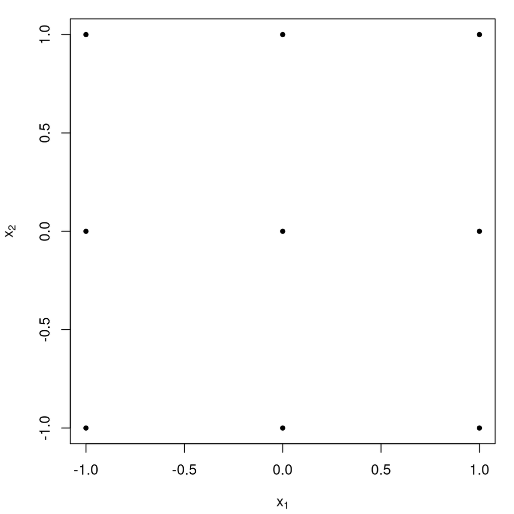

[figure not shown]

## Other examples of existing designs

- centered composite designs, see e.g., [1]:

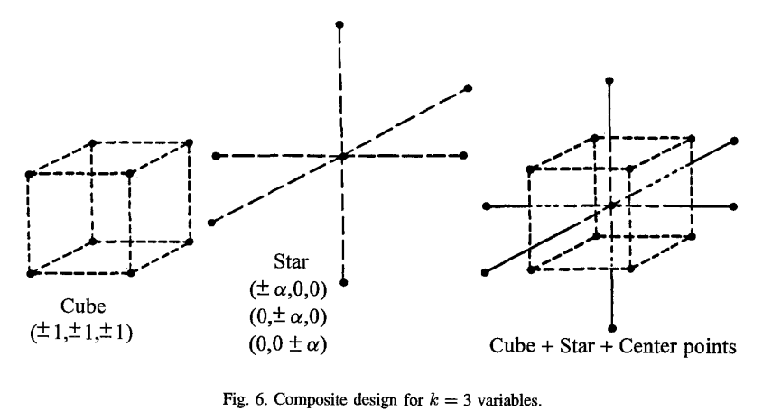

- Box-Behnken, Hoke, Doehlert, …

## Additional important notions

R.A. Fisher highlighted other additional concepts related to error control in the agricultural context:

**randomization**: performing the experiments in random order

**replication**: repeating an experiment allow to estimate the noise variance

**blocking**: repeating the same experience on the same plot (better than changing the allocation every year)

**orthogonality**: simpler computations, better statistical properties often related to optimality

## Partial summary

Pros:

- simplicity
- handle both continuous and discrete variables
- adapted to simple linear regression models and ANOVA

Cons:

- very costly for more than a few variables
- loss of information if some variables are not influential
- few points at the center of the domain

More adapted to experiments in **low-dimension**.

## Space filling designs

## Context

- continuous variables (mostly)
- model agnostic
  - can handle a large variety of models (linear regression, kriging, support vector machine, neural networks, …)
- complex output
  - non-linearity, jumps, input dependent noise, …
- large number of variables –but few may be important–
  - robust to increase of dimension
  - good projection properties

The idea is to **explore/fill** the design space as much as possible.

## Counter examples

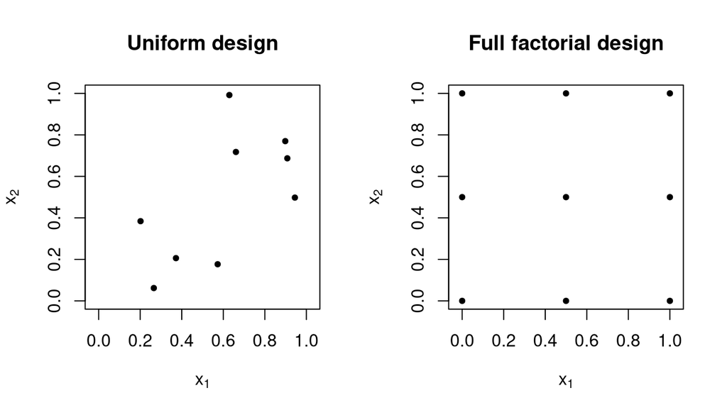

```r
# Uniform design and factorial designs
d <- 2; n <- 9
par(mfrow = c(1, 2))
plot(matrix(runif(n * d), n), xlab = expression(x[1]), ylab = expression(x[2]),
     main = "Uniform design", pch = 20, asp = 1, xlim = c(0,1), ylim = c(0,1))
plot(expand.grid(seq(0,1,,sqrt(n)), seq(0,1,,sqrt(n))), xlab = expression(x[1]),
     ylab = expression(x[2]), main = "Full factorial design", pch = 20, asp = 1)
```

```r
par(mfrow = c(1, 1))
```

## Curse of dimensionality

A regular grid of 10 points in dimension \(d\) requires \(10^d\) points

Most of the volume is concentrated on the boundary of the domain:

- volume ratio of the unit \(d\)-ball / unit \(d\)-cube \(\rightarrow 0\) as \(d \to \infty\)
- volume ratio of the \(d\)-ball of radius \(R - \delta R\) / the \(d\)-ball of radius \(R\): \(o((1 - \delta)^d)\)

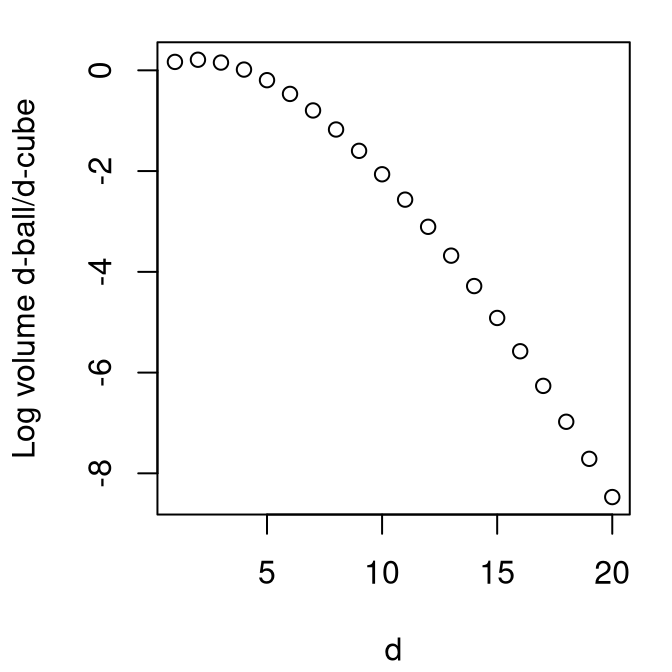

## Latin hypercube samples (LHS)

Each dimension of the design space is divided into \(n\) intervals, and the LHS is constructed such that there is a unique sample into each interval.

By construction, marginal distributions are uniform (guaranteeing some spread)

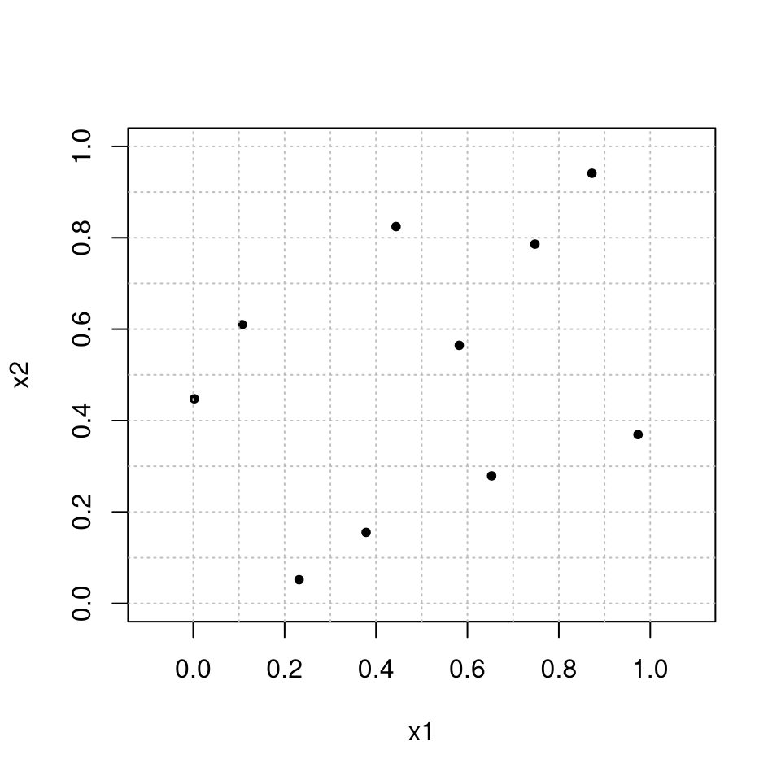

```r
library(lhs)
X <- randomLHS(10,2)
plot(X, pch = 20, asp = 1, xlim = c(0, 1), ylim = c(0, 1), xlab = "x1", ylab = "x2")
abline(h = seq(0,1,0.1), col = "gray", lty = 3)
abline(v = seq(0,1,0.1), col = "gray", lty = 3)
```

## More on LHS

- The projection of a LHS obtained by dropping coordinates remains an LHS
- **variance reduction**: if \(f\) is monotone in each coordinate, the variance of the MC integration is lower with an LHS than with a uniform sample
- non-uniform marginals: apply the associated inverse cdf on each marginal

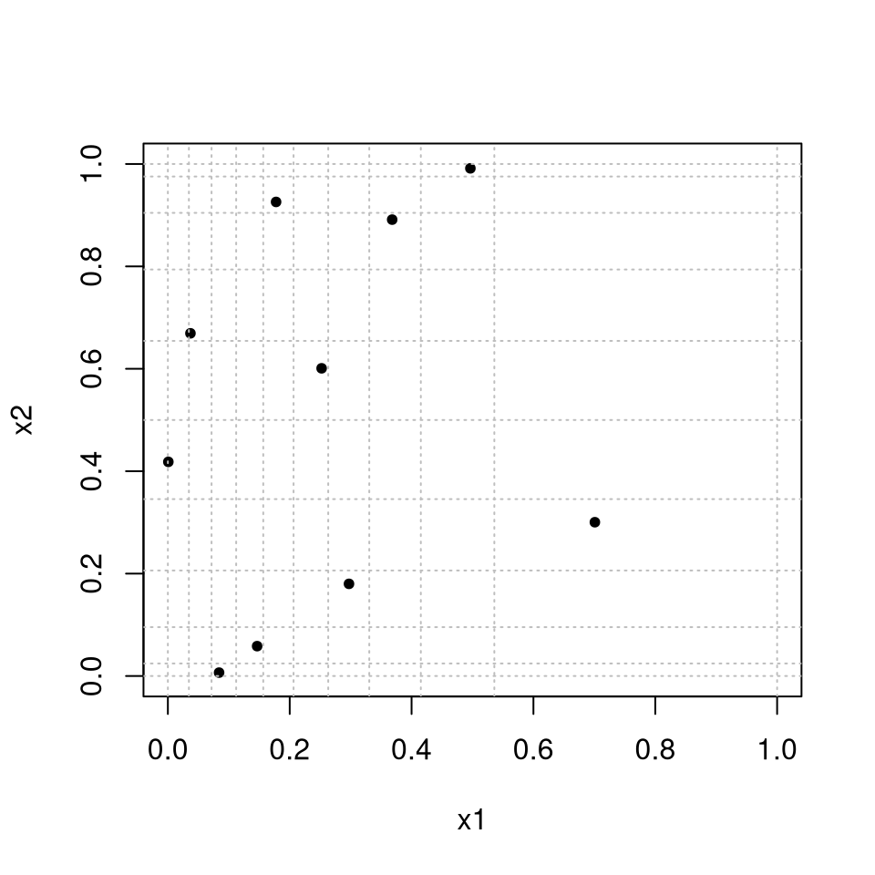

```r
Xprime[,1] <- qbeta(X[,1], shape1 = 1, shape2 = 3)
Xprime[,2] <- qbeta(X[,2], shape1 = 0.5, shape2 = 0.5)
plot(Xprime, xlim = c(0, 1), ylim = c(0,1), pch = 20, xlab = "x1", ylab = "x2")
abline(v = qbeta(seq(0,1,0.1), 1, 3), col = "gray", lty = 3)
abline(h = qbeta(seq(0,1,0.1), 0.5, 0.5), col = "gray", lty = 3)
```

## Limits of LHS

Uniform marginals do not prevent holes, clumps, patterns (especially for large \(d\))

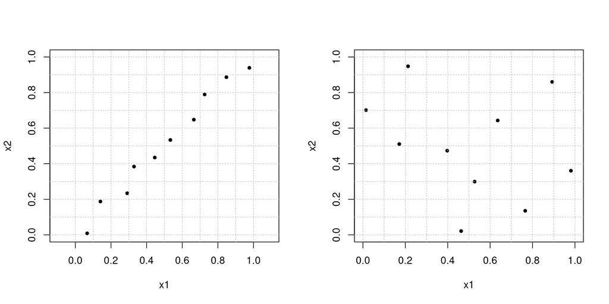

```r
X1 <- matrix(runif(20, -0.05, 0.05) + seq(0.05,0.95,0.1), 10) # worst case
X2 <- randomLHS(10,2)
par(mfrow = c(1, 2))
plot(X1, pch = 20, asp = 1, xlim = c(0, 1), ylim = c(0, 1), xlab = "x1", ylab = "x2")
abline(h = seq(0,1,0.1), col = "gray", lty = 3)
abline(v = seq(0,1,0.1), col = "gray", lty = 3)
plot(X2, xlim = c(0, 1), ylim = c(0,1), pch = 20, xlab = "x1", ylab = "x2")
abline(h = seq(0,1,0.1), col = "gray", lty = 3)
abline(v = seq(0,1,0.1), col = "gray", lty = 3)
```

```r
par(mfrow = c(1,1))
```

## LHS based on orthogonal arrays

An orthogonal array \(\mathbf{X}\) with \(n\) lines and \(k\) columns with elements in \([1, q]\) is said to be of strength \(t\) if for all \(n \times t\) sub-matrices:

- all elements appears the same number of times per column
- each combination of elements between two columns appears \(\lambda\) times

Consequently \(\lambda q^t = n\)

LHS are orthogonal arrays of strength 1.

*Example*: LHS based on a strength 2 orthogonal array obtained with `R` package [lhs](https://cran.r-project.org/web/packages/lhs/index.html)

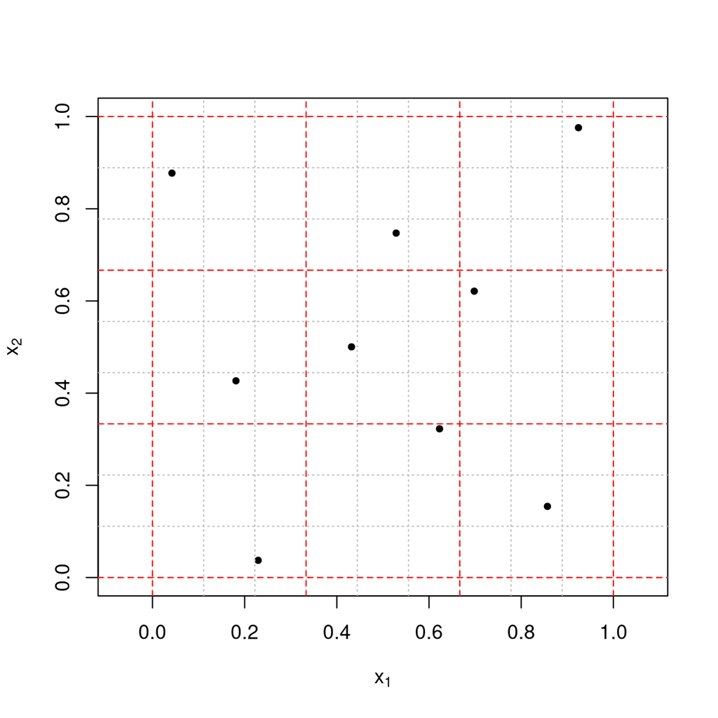

## Optimized designs

Directly build designs that are good for a given criteria. Popular criteria:

- **maximin**: maximize the minimal distance between any two design points \(\max \limits_{X_n} \min \limits_{i \neq j} ||x_i - x_j||_2^2\)
- **minimax**: minimize the maximal distance between any points of the domain and the closest design point \(\min \limits_{X_n} \max \limits_{x \in D} \min \limits_{1 \leq i \leq n} ||x_i - x||_2^2\)
- **discrepancy**: minimize the discrepancy of the design

*Example from [1](https://www.sciencedirect.com/handbook/handbook-of-statistics/vol/13/suppl/C)*

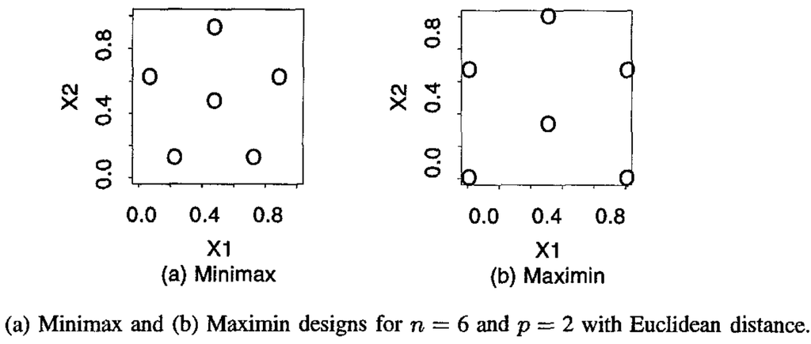

## Optimized designs (2)

The associated optimization problems are generally challenging, with no known solution:

- \(n \times d\) parameters
- multi-modal functions
- **minimax** and **discrepancy** are costly to compute, even **maximin** has complexity \(O(n^2)\)

In general, stochastic solvers are used:

- they start with an initial design
- until stopping criterion is reached:
  - select/sample a design \(\mathbf{x}^{(i)}\) to be replaced by a new one \(\mathbf{x}'\)
  - accept or reject the change based on the criteria

> LHS can be selected this way too !

## Maximin LHS samples

The most popular technique in computer experiments.

*Example with the [DiceDesign](https://cran.r-project.org/web/packages/DiceDesign/index.html) `R` package:*

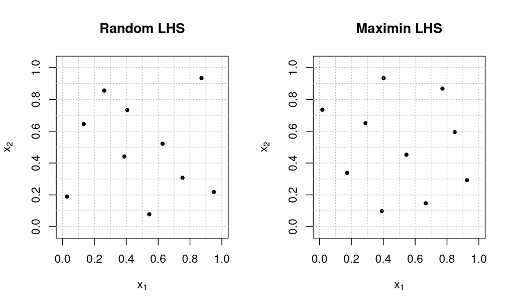

## Other space filling designs

- Voronoi and central Voronoi designs
- sphere packing, maximum entropy designs, [Strauss process designs](http://hal.archives-ouvertes.fr/hal-00260701/fr/), [maximum projection designs](https://academic.oup.com/biomet/article/102/2/371/246859), …
- no universal solution and open research directions

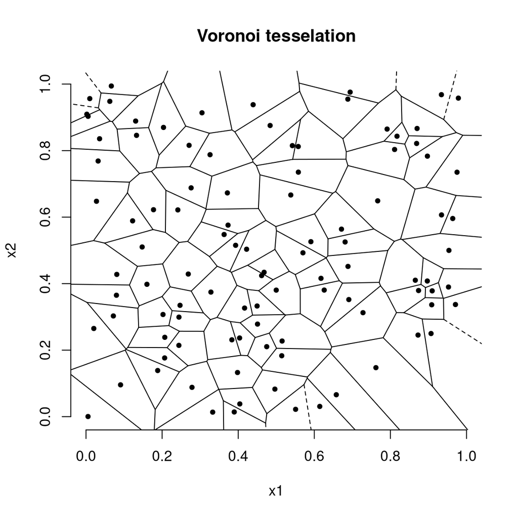

## Summary

- **Preliminary step** for: optimization, model fitting, sensitivity
- **Geometric designs**:
  - star designs, factorial designs
  - associated with linear regression
  - used for physical experiments, with a few variables, simple outputs and noise
  - neither very space filling nor robust after projection
- **Space filling designs**
  - low-discrepancy sequences, LHS
  - space is better covered, less projection issues
  - well-suited for computer experiments, scale with dimension, and complex outputs
  - adapted for sequential design

## References

- [R.B. Gramacy](https://bobby.gramacy.com/), [B. Iooss](http://www.gdr-mascotnum.fr/iooss1.html) and particularly [V. Picheny](https://sites.google.com/site/victorpicheny/) lectures on Design of experiments
- Ghosh, S., & Rao, C. R. (Eds.). (1996). Design and analysis of experiments. Amsterdam: Elsevier.
- Dean, A., Morris, M., Stufken, J., & Bingham, D. (Eds.). (2015). Handbook of design and analysis of experiments (Vol. 7). CRC Press.
- `R` packages: [DiceDesign](https://cran.r-project.org/web/packages/DiceDesign/index.html), [randtoolbox](https://cran.r-project.org/web/packages/randtoolbox/index.html), [lhs](https://cran.r-project.org/web/packages/lhs/index.html), [MaxPro](https://cran.r-project.org/web/packages/MaxPro/index.html), [planor](https://cran.r-project.org/web/packages/planor/index.html) and [many others](https://cran.r-project.org/web/views/ExperimentalDesign.html)
- (few) historical references: Fedorov, Taguchi, McKay, Sacks, …
- websites: www.spacefillingdesigns.nl , www.packomania.com